# Análise de Compras de Medicamentos, Banco de Preços de Saúde (BPS)

Thais Pereira

03/02/2024

## **Introdução**

Esse é um relatório produzido a partir do Banco de Preços de Saúde (BPS) do governo federal, com dados de 2022. Vamos fazer algumas análises exploratórias para ter uma visão geral das compras de insumos médico-hospitalares pelos estados e municípios brasileiros.

## **Visão geral de compras**

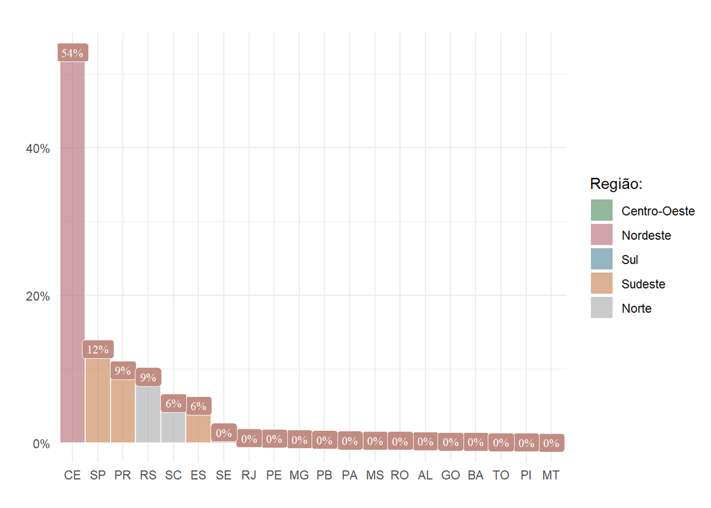

Também olhamos os principais fornecedores e listamos na tabela abaixo um ranking dos dez mais presentes e seu percentual de vendas em relação à todos os fornecedores presentes na base de dados. Podemos verificar na tabela que não há um fornecedor com percentual de vendas muito maior do que a maioria, o máximo de vendas que um fornecedor consegue é 6% do total, podemos dizer que não temos um fornecedor com grande monopólio, como acontece em outros setores.

| Fornecedor | Percentual de vendas |
| --- | --- |
| Prati, Donaduzzi E Cia Ltda | 0.0600336095497479 |
| Ems S/A | 0.0471402908964478 |
| Hipolabor Farmaceutica Ltda | 0.0432143478008924 |
| Cristalia Produtos Quimicos E Farmaceuticos Ltda | 0.0392159703308802 |
| Laboratorio Teuto Brasileiro S/A | 0.0286840122848699 |
| Geolab Industria Farmacêutica Ltda | 0.0236860404473547 |
| Cristalia Produtos Quimicos Farmaceuticos Ltda | 0.0225126035811555 |
| Eurofarma Laboratorios Ltda | 0.0207162310946283 |
| Farmace - Industria Quimico-Farmaceutica Cearense Ltda | 0.0202526510981051 |
| Cimed Industria De Medicamentos Ltda | 0.0168192617488555 |

Olhando agora os fornecedores e sua presença nas regiões, podemos ver que também não há monopólios grandes. A fornecedora Medigram tem 9% de vendas na região Sul sendo a empresa que mais vende para uma determinada região, no entando os outros percentual são bem próximos, no sudeste podemos imaginar que tenha mais variedade de fornecedores, já que a empresa que mais vende, alcança apenas 3% do total de vendas na região.

| Regiao | Fornecedor | Percentual de Vendas na Região |
| --- | --- | --- |
| Centro-Oeste | Inovamed Comercio De Medicamentos Ltda - Epp | 0.0711372904395106 |
| Nordeste | Sao Marcos Distribuidora De Medicamentos, Equipamentos E Material Hospitalares E Odontologicos Ltda | 0.0714646646935682 |
| Norte | Parafarma Medicamentos E Hospitalar Ltda | 0.0450195737277077 |
| Sudeste | Cristalia Produtos Quimicos E Farmaceuticos Ltda | 0.0328795811518325 |
| Sul | Medigram Distribuidora De Medicamentos Ltda - Me | 0.0935032304379038 |

## **Comportamento de compras**

Analisando o alcance das fornecedoras em relação à quantidade de cidades e estados, selecionamos para essa análise as cinco regiões que fornecem insumos para a maior quantidade de cidades, e podemos ver que apenas uma empresa alcança mais de cem cidades, a Inovamed, ela também está presente em 15 estados em 5 regiões. Isso nos mostra que algumas empresas, não apenas uma ou duas, não tem um carácter regional, mas possuem capacidade de fornecimento para muitas cidades e regiões ao mesmo tempo.

| Fornecedor | Qtd de cidades | Qtd de estados | Qtd de regiões |
| --- | --- | --- | --- |
| Inovamed Comercio De Medicamentos Ltda - Epp | 103 | 15 | 5 |
| Promefarma Representações Comerciais Ltda | 87 | 10 | 5 |
| Cristalia Produtos Quimicos E Farmaceuticos Ltda | 84 | 15 | 5 |
| Dimaster - Comercio De Produtos Hospitalares Ltda | 78 | 12 | 5 |
| Altermed Material Medico Hospitalar Ltda | 77 | 5 | 3 |

## **Preço pago por item**

Para fazer uma análise de preços de medicamentos, escolhemos o medicamento “LOSARTANA POTÁSSICA, DOSAGEM:50 MG” para uma análise mais detalhada. Estávamos interessados em saber qual estado pagou o preço máximo por esse insumo, e para uma visualização mais detalhada produzimos uma tabela com a informação de todas as compras desse remédio. Observando a tabela descobrimos que a maioria dos estados pagaram menos de R$ 1 real sendo que o Pauí chegou a pagar 172 reais. Mesmo Ceará e São Paulo tendo pagado um valor acima que os demais estados, cerca de 4 e 5 vezes a mais, o valor do Paiuí parece incorreto. Para seguir com as análises a recomendação seria checar esse valor ou tirar da base de dados para uma análise mais fidedigna, como mostraremos a seguir esse valor pode gerar ruídos em médias por região, por exemplo. De qualquer forma, o valor desse insumo variou bastante entre as diferentes compras, chegando a custar 4 centavos em algumas compras e quase 1 real em outras.

| Estado | preço unitário |
| --- | --- |
| PI | 172.7 |
| CE | 5.6 |
| PI | 4.87 |
| SP | 1.21 |
| MG | 0.8 |
| MG | 0.8 |
| MG | 0.73 |
| MG | 0.73 |
| SP | 0.56 |
| RJ | 0.45 |

[output cut: 153 more lines]

[figure not shown]

Para entender essa diferença de pagamento pelo mesmo item entre os diferentes estados e regiões brasileiras, olhamos se a unidade de medida comprada era a mesma, e vimos que de fato o medicamento foi comprado em comprimido por todas os estados, e também checamos se a quantidade comprada poderia estar influenciando o valor, ou seja, quanto maior a quantidade de itens do mesmo medicamento menor o valor pago na unidade. Para essa análise olhamos a quantidade média de itens desse medicamento comprado por todos os estados e colocamos num gráfico de barras que pode ser visualizado abaixo. Podemos ver que a quantidade comprada pelo Ceará e pelo Piaui de fato foi bem pequena, o que pode, em parte, explicar o preço maior pago. Minas Gerais no gráfico anterior pagou o maior valor médio pelo medicamento e no gráfico abaixo comprou a menor quantidade média do mesmo insumo. Os dados de Sergipe e Bahia também parecem confirmar essa hipótese.

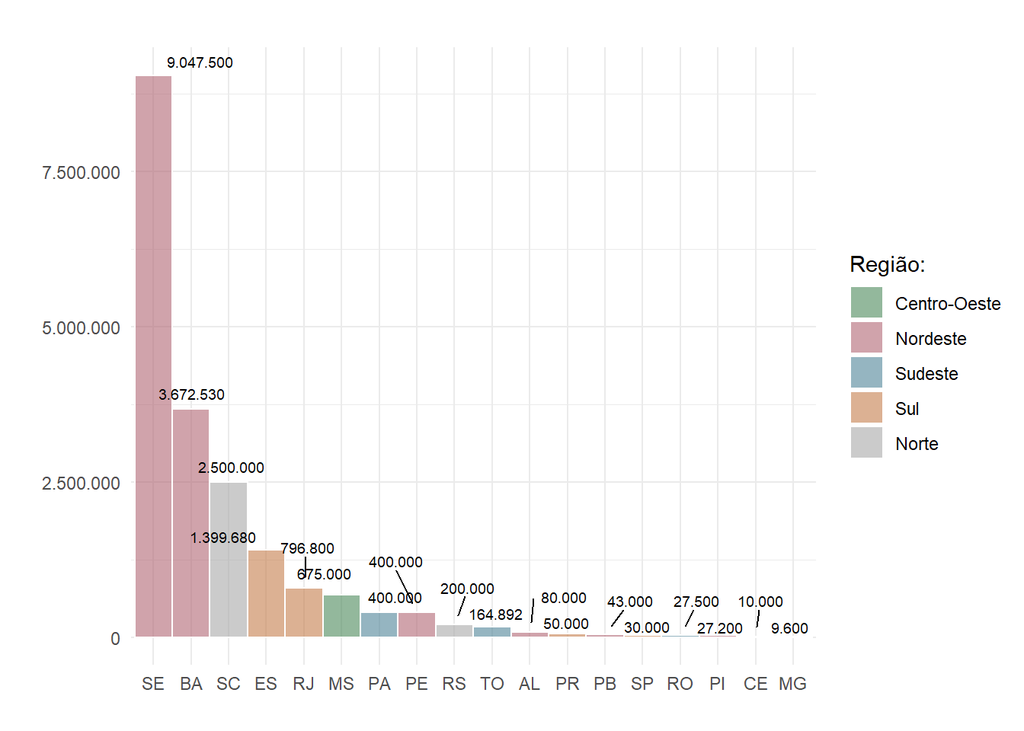

Por último olhamos o quanto cada região pagou por esse medicamento, fizemos uma coluna com os dois grandes outliers (PI e CE), apenas a título de verificação, e uma outra coluna sem os dois dados extremos. Percebemos que eles realmente fazem diferença nos valores médios e por isso é sempre útil olhar os dados no detalhe, com um histograma por exemplo, ou os valores máximos e mínimos da base de dados antes de olhar para os valores médios. A região sul foi a que pagou menos pelo insumo, seguido da região centro-oeste.

| Estado | Média preco unitário | Média preço unitário sem outliers |
| --- | --- | --- |
| Nordeste | 4.45 | 0.07 |
| Sudeste | 0.13 | 0.13 |
| Norte | 0.07 | 0.07 |
| Centro-Oeste | 0.06 | 0.06 |
| Sul | 0.05 | 0.05 |

A última análise diz respeito a modalidade de compra, gostaríamos de saber se ela influencia no preço do insumo. Para essa análise buscamos o insumo mais comprado no ano de 2022 e analisamos se o seu preço foi influenciado pela modalidade de compra. A tabela abaixo nos mostra que, de fato, há uma grande influencia, atavés da concorrência o insumo podemos custar menos da metade do valor que ele custa por meio Tomada de Preços. Seria necessário analisar mais insumos para confirmar essa hipótese, mas aqui podemos formular que a concorrência é a forma mais barata de se comprar insumos-médicos. Precisamos verificar numa análise mais detalhada se ela é a mais frequente, e onde ela é menos frequente.

| Modalidade da Compra | Média de preço unitário |
| --- | --- |
| Concorrência | 3.2 |
| Pregão | 5.67 |
| Dispensa de Licitação | 6.44 |
| Tomada de Preços | 8.3 |

Devido ao resultado anterior resolvemos entender qual tipo de modalidade de compra é mais frequente, e descobrimos que apesar de produzir um valor menor de compra, a concorrência é uma das modalidades menos frequentes, enquanto o pregão é a modalidade mais frequente empregada para a compra de insumos-médios hospitalares.

| Modalidade da Compra | Média de preço unitário |
| --- | --- |
| Convite | 1.44868748913484e-05 |
| Inexigibilidade de Licitação | 0.00312916497653126 |
| Concorrência | 0.00533116996001623 |
| Tomada de Preços | 0.0125746074056904 |
| Dispensa de Licitação | 0.0436344671727415 |
| Pregão | 0.935316103610129 |

## **Conclusão**

Conduzimos nesse relatório uma breve análise da base de dados Compras de Medicamentos, Banco de Preços de Saúde (BPS). Com ela é possíve tirar vários insights que podem contribuir com a melhor gestão das compras públicas de insumos-médicos. Outras bases de dados públicas podem contribuir com essas análises, como a Munic, que disponibiliza informações básicas municipais, e seria interessante para entender as características dos munícípios e seus padrões de compras. Mas mesmo utilizando apenas essa base de dados já é possível obter muitas informações relevantes, pretemos seguir com as análises e aprofundar hipóteses levantadas nesse relatório.